# Example 7: The two-dimensional Poisson problem

[Niall Madden](https://www.niallmadden.ie/) *Jan 2025*

This notebook discusses how to solve a (stationary) elliptic problem in two dimensions. We'll base our example on the standard Poisson's Equation. However, this notebook really just presents a simplified version of the Helmholtz example in the Firedrake documentation: https://www.firedrakeproject.org/demos/helmholtz.py.html

## What this notebook does

We'll consider methods for solving Poisson's Equation: *find $u=u(x,y)$ such that* $$u_{xx}(x,y) + u_{yy}(x,y) = f(x,y), \qquad \text{ for } (x,y) \in \Omega :=(0,1)^2,$$ and subject to boundary condition $u|_{\partial \Omega}=0$.

For the example in this notebook, we'll construct the problem so that the solution is $u(x,y)=16x(1-x)y(1-y)$. This is chosen because it is simple, it satisfies the boundary conditions, and one can check that $u(1/2,1/2)=1$.

## Usual Firedrake and Jupyter preliminaries

```python
import os
if "OMP_NUM_THREADS" not in os.environ:
    os.environ["OMP_NUM_THREADS"] = "1"
from firedrake import *
import numpy as np
```

Since we'll be visualising two-dimensional functions, we need some extras:

```python
%matplotlib notebook
import matplotlib.pyplot as plt
from mpl_toolkits import mplot3d
from firedrake.pyplot import tripcolor, tricontour, triplot
```

## The test problem

We specify the true solution, and then choose $f$:

```python
def u_e(x,y): return 16*x*(1-x)*y*(1-y) # exact solution
def f(x,y): return -32*(x*(1-x)+y*(1-y))
```

## The mesh and FEM space

In 2D, we have more choices for how to construct even a "uniform", and also on how to define a function space on that mesh. Here we'll only focus on the first issue. We'll start by building a mesh using the `UnitSquareMesh` function. You should read more about that function at https://www.firedrakeproject.org/_modules/firedrake/utility_meshes.html

```python
N = 8   # number of mesh intervals in space
mesh2D = UnitSquareMesh(N,N)
```

When $N$ is small, it can be useful to visualise the mesh:

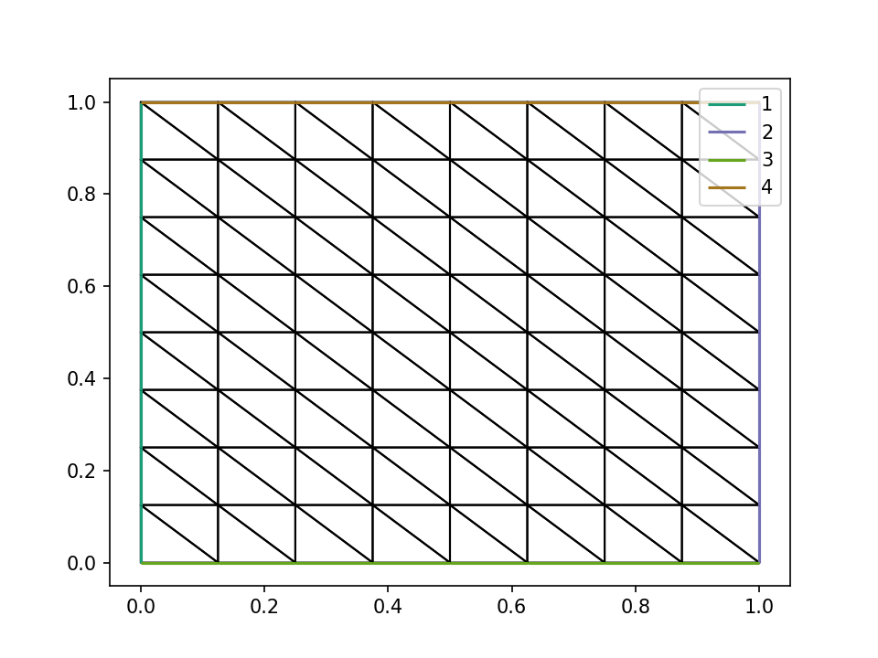

```python
fig, axes = plt.subplots()
triplot(mesh2D, axes=axes)
axes.legend()
```

```python
Ue = FiniteElement("CG", mesh2D.ufl_cell(), 1)
V = FunctionSpace(mesh2D, Ue)
x,y = SpatialCoordinate(mesh2D)
rhs = Function(V).interpolate(f(x,y))
```

## Implementation

The PDE is $$-(u_{xx}(x,y) + u_{yy}(x,y)) = -f(x,y),$$ where we have change sign for convenience. The variational form is: *find $u\in H^1_0(\Omega)$ such that* $$ -\int_0^1 \int_0^1 (u_{xx}(x,y) + u_{yy}(x,y))v(x,y) dxdy = -\int_0^1 \int_0^1 f(x,y)v(x,y)dx dy$$ *for all $v \in H^1_0(\Omega)$*. However, we'll simplify this notation as $$ -\int_\Omega (u_{xx} + u_{yy})v d \mathbf{x} = -\int_\Omega f v d \mathbf{x},$$ where $\mathbf{x}$ denotes $(x,y)$. Integrating by parts, and exploiting the boundary conditions gives $$ \int_\Omega u_{x}v_x + u_y v_y d \mathbf{x} = -\int_\Omega f v d \mathbf{x},$$

```python
u = TrialFunction(V)
v = TestFunction(V)

a = (u.dx(0)*v.dx(0) + u.dx(1)*v.dx(1))*dx
L = -inner(rhs,v)*dx

BC = DirichletBC(V, 0.0, "on_boundary")
uN = Function(V)
solve(a == L, uN, bcs=BC)
```

Check the error:

```python
u_true = Function(V).interpolate(u_e(x,y))
Err_L2 = errornorm(u_true, uN, norm_type='L2')
print(f"N={N}, ||u-uN||_0={Err_L2:.2e}")
```

[output not shown]

## Plot solutions

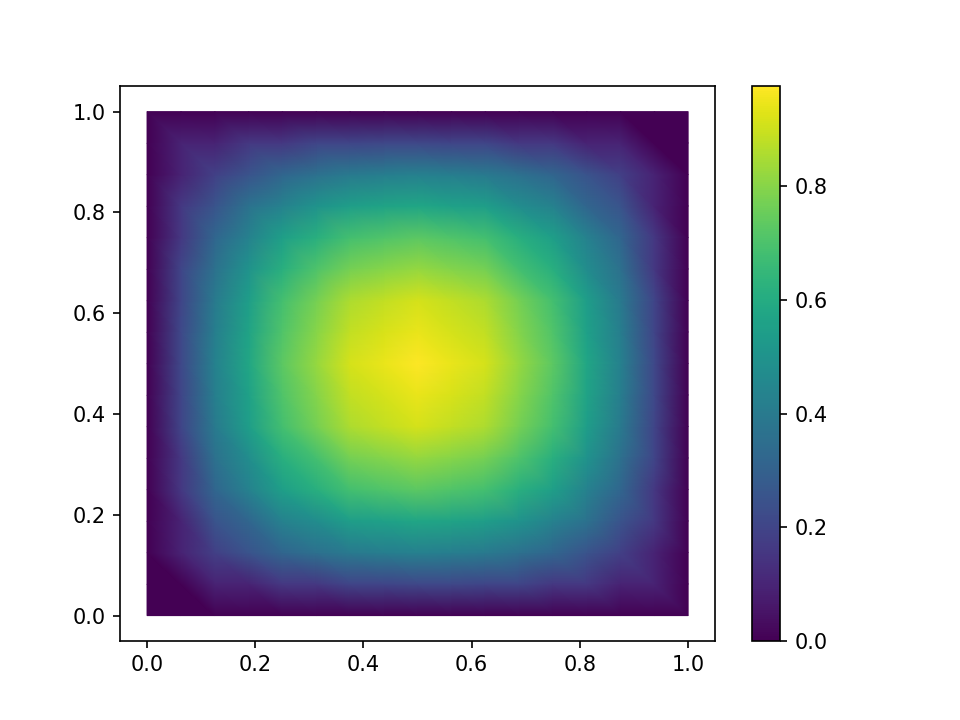

```python
fig, axes = plt.subplots()
colors = tripcolor(uN, axes=axes)
fig.colorbar(colors)
```

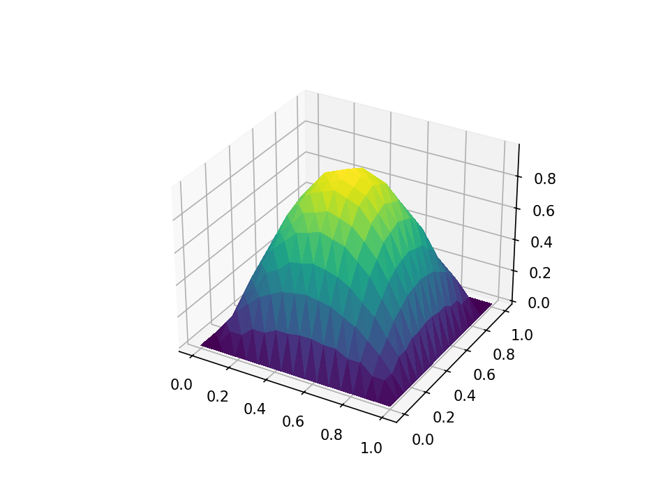

```python
fig = plt.figure()
axes = fig.add_subplot(projection='3d')
trisurf(uN, axes=axes);
```

## Exercises

1. Verify the order of convergence of the method, in both the $L_2$ and $H_1$ norms.
2. The example above uses $P_1$ elements. Try using higher-order elements.
3. Read up on the `UnitSquareMesh` function at https://www.firedrakeproject.org/_modules/firedrake/utility_meshes.html. Note that one can pass a optional parameter `diagonal` with any one of three values: `"crossed"`, `"left"`, `"right"`. Try these. Notice any qualatative or quantatative differences in the solutions and errors?
4. In the above example, we used triangular mesh. We could also try a quadrilateral mesh by defining `mesh2D = UnitSquareMesh(N,N, quadrilateral=True)`. Try this. You should find that, even with $Q_1$ elements, the error is close to machine epsilon for any $N$. Why do you think that is? Try constructing a problem for which the error is not vanishingly small.